# Vegan-specific signature implies healthier metabolic profile: findings from diet-related multi-omics observational study based on different European populations

- Show All Code
- Hide All Code
- View Source

Statistical report for metabolom analysis

**Authors and affiliations**

Anna Ouradova<sup>1,*</sup>, Giulio Ferrero<sup>2,3,*</sup>, Miriam Bratova<sup>4</sup>, Nikola Daskova<sup>4</sup>, Alena Bohdanecka<sup>4,5</sup>, Klara Dohnalova<sup>6</sup>, Marie Heczkova<sup>4</sup>, Karel Chalupsky<sup>6</sup>, Maria Kralova<sup>7,8</sup>, Marek Kuzma<sup>9</sup>, István Modos<sup>4</sup>, Filip Tichanek<sup>4</sup>, Lucie Najmanova<sup>9</sup>, Barbara Pardini<sup>10</sup>, Helena Pelantová<sup>9</sup>, Sonia Tarallo<sup>10</sup>, Petra Videnska<sup>11</sup>, Jan Gojda<sup>1,#</sup>, Alessio Naccarati<sup>10,#</sup>, Monika Cahova<sup>4,#</sup>

* These authors have contributed equally to this work and share first authorship  
<sup>#</sup> These authors have contributed equally to this work and share last authorship

<sup>1</sup> Department of Internal Medicine, Kralovske Vinohrady University Hospital and Third Faculty of Medicine, Charles University, Prague, Czech Republic  
<sup>2</sup> Department of Clinical and Biological Sciences, University of Turin, Turin, Italy  
<sup>3</sup> Department of Computer Science, University of Turin, Turin, Italy  
<sup>4</sup> Institute for Clinical and Experimental Medicine, Prague, Czech Republic  
<sup>5</sup> First Faculty of Medicine, Charles University, Prague, Czech Republic  
<sup>6</sup> Czech Centre for Phenogenomics, Institute of Molecular Genetics of the Czech Academy of Sciences, Prague, Czech Republic  
<sup>7</sup> Ambis University, Department of Economics and Management, Prague, Czech Republic  
<sup>8</sup> Department of Informatics, Brno University of Technology, Brno, Czech Republic  
<sup>9</sup> Institute of Microbiology of the Czech Academy of Sciences, Prague, Czech Republic  
<sup>10</sup> Italian Institute for Genomic Medicine (IIGM), c/o IRCCS Candiolo, Turin, Italy  
<sup>11</sup> Mendel University, Department of Chemistry and Biochemistry, Brno, Czech Republic

This is a statistical report of the study *A vegan diet signature from a multi-omics study on different European populations is related to favorable metabolic outcomes* that is currenlty *under review*

When using this code or data, cite the original publication:

BibTex citation for the original publication:

Original [GitHub repository](https://github.com/filip-tichanek/ItCzVegans): https://github.com/filip-tichanek/ItCzVegans

Statistical **reports** can be found on the [reports hub](https://filip-tichanek.github.io/ItCzVegans/).

Data analysis is described in detail in the [statistical methods](https://filip-tichanek.github.io/ItCzVegans/html_reports/478_code04_methods.html) report.

# 1 Introduction

This project explores potential signatures of a vegan diet across the microbiome, metabolome, and lipidome. We used data from healthy vegan and omnivorous human subjects in two countries (Czech Republic and Italy), with subjects grouped by `Country` and `Diet`, resulting in four distinct groups.

To assess the generalizability of these findings, we validated our results with an independent cohort from the Czech Republic for external validation.

## 1.1 Statistical Methods

The statistical modeling approach is described in detail in [this report](https://filip-tichanek.github.io/ItCzVegans/html_reports/478_code04_methods.html). Briefly, the methods used included:

- **Multivariate analysis**: We conducted multivariate analyses (PERMANOVA, PCA, correlation analyses) to explore the effects of `diet`, `country`, and their possible interaction (`diet : country`) on the microbiome, lipidome, and metabolome compositions in an integrative manner. This part of the analysis is not available on the GitHub page, but the code will be provided upon request.
- **Linear models**: Linear models were applied to estimate the effects of `diet`, `country`, and their interaction (`diet:country`) on individual lipids, metabolites, bacterial taxa and pathways (“features”). Features that significantly differed between diet groups (based on the estimated average conditional effect of diet across both countries, adjusted for multiple comparisons with FDR < 0.05) were further examined in the independent external validation cohort to assess whether these associations were reproducible. Next, we fit linear models restricted to vegan participants to test whether omics profiles varied with the duration of vegan diet. Fixed-effect predictors were diet duration (per 10 years), country, their interaction, and age (included due to correlation with diet duration).
- **Predictive models (elastic net)**: We employed elastic net logistic regression (via the `glmnet` R package) to predict vegan status based on metabolome, lipidome, microbiome and pathways data (one model per dataset; four models in total). We considered three combinations of Lasso and Ridge penalties (alpha = 0, 0.2, 0.4). For each alpha, we selected the penalty strength (λ<sub>1se</sub>) using 10-fold cross-validation. This value corresponds to the most regularized model whose performance was within one standard error of the minimum deviance. The alpha–lambda pair with the lowest deviance was chosen to fit the final model, whose coefficients are reported.  
  To estimate model performance, we repeated the full modeling procedure (including hyperparameter tuning) 500 times on bootstrap resamples of the training data. In each iteration, the model was trained on the resampled data and evaluated on the out-of-bag subjects (i.e., those not included in the training set in that iteration). The mean, and 2.5th, and 97.5th percentiles of the resulting ROC-AUC values represent the estimated out-of-sample AUC and its 95% confidence interval.  
  Finally, the final model was applied to an independent validation cohort to generate predicted probabilities of vegan status. These probabilities were then used to assess external discrimination between diet groups (ROC-AUC in the independent validation cohort). The elastic net models were not intended for practical prediction, but to quantify the strength of the signal separating the dietary groups, with its uncertainty, by using all features of a given dataset jointly. It also offered a complementary perspective on which features are most clearly associated with diet

# 2 Initiation

## 2.1 Set home directory

**Open code**

```r
setwd('/home/ticf/1_ticf_sec/478_MOCA_italian/')
```

## 2.2 Upload initiation file

**Open code**

```r
source('478_initiation.R')
```

# 3 Data

## 3.1 Upload all original data

### 3.1.1 Training set

**Open code**

```r
data_metabolites_original <- read.xlsx('gitignore/data/serum_metabolome_training_cohort.xlsx')
```

### 3.1.2 Validation set

**Open code**

```r
data_metabolites_validation <- read.xlsx('gitignore/data/Serum_metabolome_Validation_cohort_new.xlsx') %>%
  select(-X38)
```

### 3.1.3 Merge training and validation dataset

**Open code**

```r
tr1 <- data_metabolites_original %>%
  mutate(Data = if_else(Country == 'CZ', 'CZ_tr', 'IT_tr')) %>%
  select(Data, Diet, `formate`:`2-hydroxybutyrate`)

tr2 <- data_metabolites_validation %>%
  mutate(Data = 'valid',
         Diet = if_else(SKUPINA == 0 , 'OMNI', 'VEGAN')) %>%
  select(Data, Diet, `formate`:`2-hydroxybutyrate`)

data_merged <- bind_rows(tr1, tr2)
```

## 3.2 Explore

### 3.2.1 Distributions - raw data

**Open code**

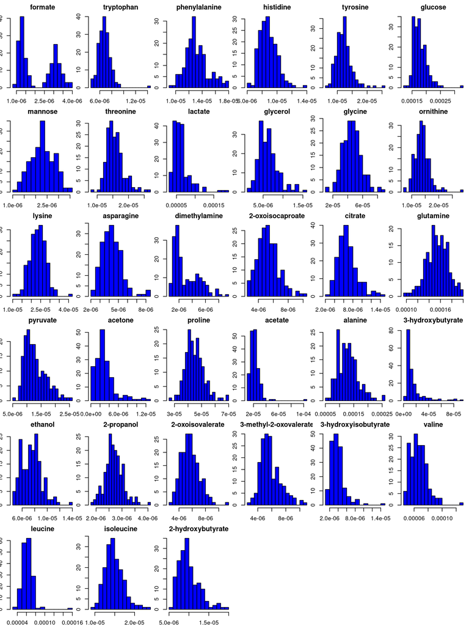

```r
check <- data_metabolites_original %>%
  dplyr::select(
    `formate`: `2-hydroxybutyrate`
    ) %>%
  na.omit()


size = c(6,6)
par(mfrow = c(size[1],size[2]))
par(mar=c(2,1.5,2,0.5))
set.seed(16)

for(x in 1:ncol(check)){
  hist(check[,x],
       16,
       col='blue',
       main = paste0(colnames(check)[x])
  )
}
```

Data seems to be highly right-tailed

### 3.2.2 Distribution - Log2 transformed

**Open code**

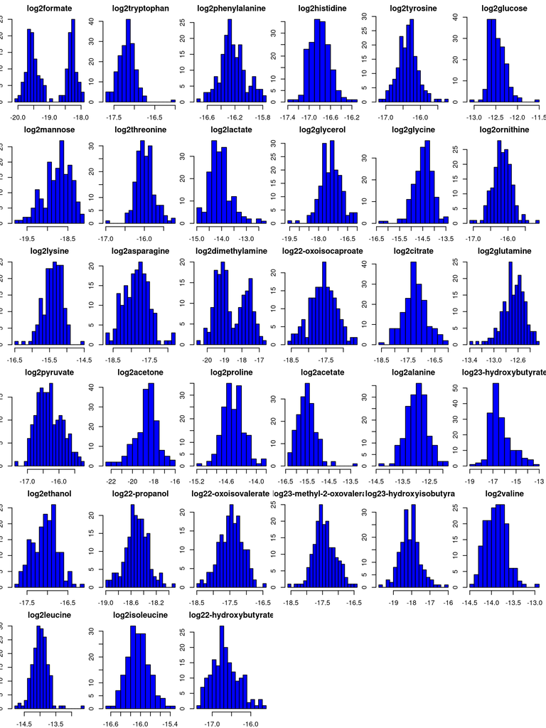

```r
par(mfrow = c(size[1],size[2]))
par(mar=c(2,1.5,2,0.5))
set.seed(16)

for(x in 1:ncol(check)){
  hist(log2(check[,x]+1e-8),
       16,
       col='blue',
       main = paste0('log2',colnames(check)[x])
  )
}
```

Seems more symmetrical and Gaussian

#### 3.2.2.1 Comparison training vs validation cohort

**Open code**

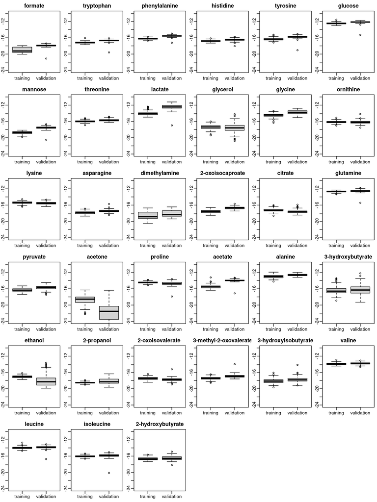

```r
tr1 <- data_metabolites_original %>%
  select(formate:`2-hydroxybutyrate`) %>%
  mutate(dataset = 'training')

tr2 <- data_metabolites_validation %>% select(formate:`2-hydroxybutyrate`) %>%
  mutate(dataset = 'validation')

tr <- bind_rows(tr1, tr2)

size = c(6,6)
par(mfrow = c(size[1],size[2]))
par(mar = c(2,1.5,2,0.5))
par(mgp = c(3, 0.5, 0 ))

for(x in 1:(ncol(tr)-1)){
  plot(log2(tr[, x]) ~ factor(tr$dataset),
       main = paste0(colnames(check)[x]),
       ylim = c(-24, -10)
  )
}
```

#### 3.2.2.2 Metabolites accross groups

**Open code**

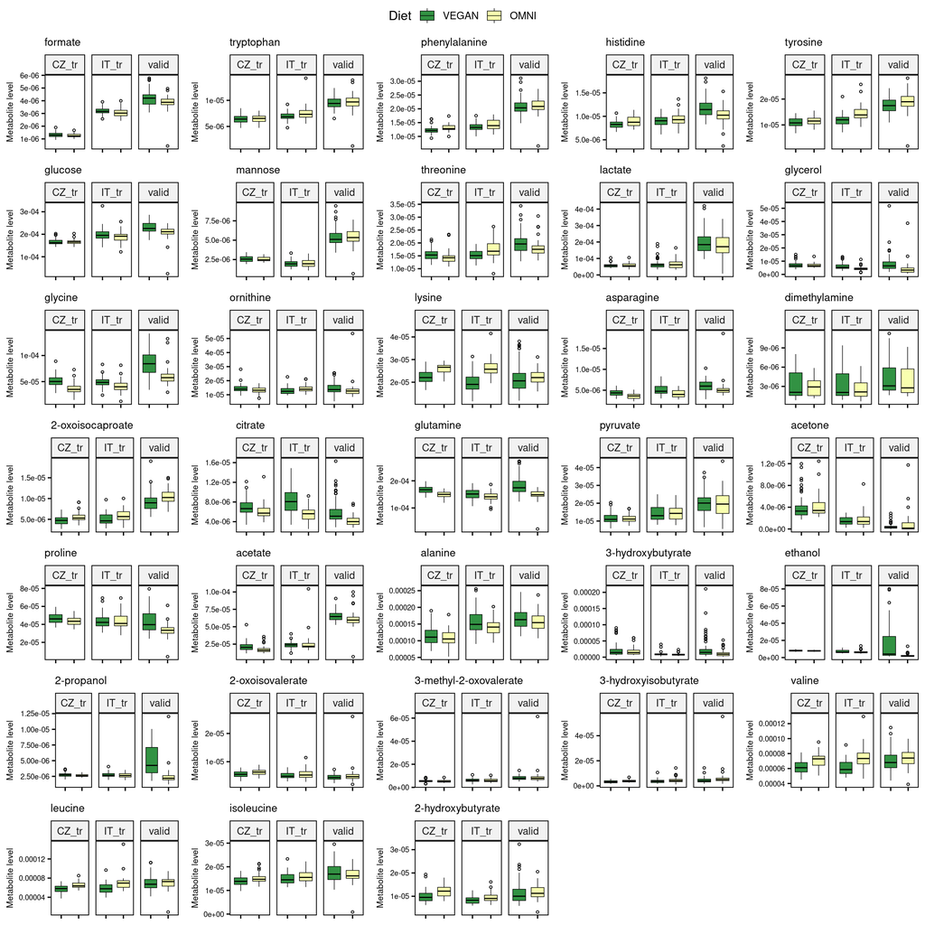

Levels of metabolites across all 3 cohorts (Czech and Italian training cohorts and an independent Czech valdiation cohort) and across dietary groups

```r
colo <- c('#329243', '#F9FFAF')

outcomes <- data.frame(
  variable = data_merged %>%
    select(formate:`2-hydroxybutyrate`) %>%
    colnames())

boxplot_cond <- function(variable) {


  p <- ggboxplot(data_merged,
                 x = 'Diet',
                 y = variable,
                 fill = 'Diet',
                 tip.length = 0.15,
                 palette = colo,
                 outlier.shape = 1,
                 lwd = 0.25,
                 outlier.size = 0.8,
                 facet.by = 'Data',
                 title = variable,
                 ylab = 'Metabolite level') +

    theme(
      plot.title = element_text(size = 10),
      axis.title = element_text(size = 8),
      axis.text.y = element_text(size = 7),
      axis.text.x = element_blank(),
      axis.title.x = element_blank()
    )


  return(p)
}

# Plot all outcomes
plots <- map(outcomes$variable, boxplot_cond)

# Create a matrix of plots
plots_arranged <- ggarrange(plotlist = plots, ncol = 5, nrow = 7,  common.legend = TRUE)
plots_arranged
```

# 4 Linear models across metabolites

We will fit a feature-specific linear model where the log2-transformed metabolite represents the outcome variable whereas `country` (Italy vs Czech), `diet` (vegan vs omnivore), and their interaction (`country:diet`) all represent fixed-effects predictors. So, each model has following form

$$log_{2}(\text{metabolite level}) = \alpha + \beta_{1} \times \text{country} + \beta_{2} \times \text{diet} + \beta_{3} \times \text{country:diet} + \epsilon$$

The variables were coded as follows: $diet = -0.5$ for omnivores and $diet = 0.5$ for vegans; $country = -0.5$ for the Czech cohort and $country = 0.5$ for the Italian cohort.  
This parameterization allows us to interpret the linear model `summary` output as presenting the conditional effects of `diet` averaged across both countries and the conditional effects of `country` averaged across both diet groups. We will then use the `emmeans` package (Lenth 2024) to obtain specific estimates for the effect of `diet` in the Italian and Czech cohorts separately, still from a single model.

Metabolites that will show a significant diet effect (average effect of `diet` across both countries, adjusted for multiple comparisons with FDR < 0.05) will be then visualized using a forest plot, with country-specific diet effect along with diet effect based on independent validation cohort, to evaluate how generalizable are these findings.

## 4.1 Define transformation function for each dataset

Given the distribution of the estimated metabolites concentrations, we will use log2-transformed values

**Open code**

```r
trans_metabolite <- function(x){
  log2(x + 1e-8)
}
```

## 4.2 Select and wrangle data

**Open code**

```r
data_analysis_metabolom <- data_metabolites_original %>%
  na.omit() %>%
  dplyr::mutate(
    Diet_VEGAN = as.numeric(
      dplyr::if_else(
        Diet == "VEGAN", 0.5, -0.5
      )
    ),
    Country_IT = as.numeric(
      dplyr::if_else(
        Country == "IT", 0.5, -0.5
      )
    ),
    dplyr::across(
      `formate`: `2-hydroxybutyrate`, ~ trans_metabolite(.)
    )
  ) %>%
  dplyr::select(
    Sample,
    Country,
    Country_IT,
    Diet,
    Diet_VEGAN,
    Group,
    dplyr::everything()
  )

summary(data_analysis_metabolom[ , 1:12])
##     Sample            Country            Country_IT           Diet
##  Length:173         Length:173         Min.   :-0.50000   Length:173
##  Class :character   Class :character   1st Qu.:-0.50000   Class :character
##  Mode  :character   Mode  :character   Median :-0.50000   Mode  :character
##                                        Mean   :-0.04913
##                                        3rd Qu.: 0.50000
##                                        Max.   : 0.50000
##    Diet_VEGAN          Group              formate         tryptophan
##  Min.   :-0.50000   Length:173         Min.   :-20.03   Min.   :-17.69
##  1st Qu.:-0.50000   Class :character   1st Qu.:-19.59   1st Qu.:-17.32
##  Median : 0.50000   Mode  :character   Median :-19.25   Median :-17.17
##  Mean   : 0.07803                      Mean   :-18.98   Mean   :-17.18
##  3rd Qu.: 0.50000                      3rd Qu.:-18.30   3rd Qu.:-17.07
##  Max.   : 0.50000                      Max.   :-17.93   Max.   :-16.10
##  phenylalanine      histidine         tyrosine         glucose
##  Min.   :-16.70   Min.   :-17.31   Min.   :-17.17   Min.   :-13.00
##  1st Qu.:-16.34   1st Qu.:-16.93   1st Qu.:-16.55   1st Qu.:-12.61
##  Median :-16.25   Median :-16.80   Median :-16.34   Median :-12.50
##  Mean   :-16.23   Mean   :-16.80   Mean   :-16.36   Mean   :-12.47
##  3rd Qu.:-16.12   3rd Qu.:-16.67   3rd Qu.:-16.20   3rd Qu.:-12.34
##  Max.   :-15.76   Max.   :-16.16   Max.   :-15.25   Max.   :-11.58
```

### 4.2.1 Define number of metabolites and covariates

**Open code**

```r
n_covarites <- 6
n_features <- ncol(data_analysis_metabolom) - n_covarites
```

### 4.2.2 Create empty objects

**Open code**

```r
outcome <- vector('double', n_features)
log2FD_VGdiet_inCZ <- vector('double', n_features)
log2FD_VGdiet_inIT <- vector('double', n_features)
log2FD_VGdiet_avg <- vector('double', n_features)

log2FD_ITcountry_avg <- vector('double', n_features)
diet_country_int <- vector('double', n_features)


P_VGdiet_inCZ <- vector('double', n_features)
P_VGdiet_inIT <- vector('double', n_features)
P_VGdiet_avg <- vector('double', n_features)

P_ITcountry_avg <- vector('double', n_features)
P_diet_country_int <- vector('double', n_features)

CI_L_VGdiet_inCZ <- vector('double', n_features)
CI_L_VGdiet_inIT <- vector('double', n_features)
CI_L_VGdiet_avg <- vector('double', n_features)

CI_U_VGdiet_inCZ <- vector('double', n_features)
CI_U_VGdiet_inIT <- vector('double', n_features)
CI_U_VGdiet_avg <- vector('double', n_features)
```

## 4.3 Run linear models over metabolites

**Open code**

```r
for (i in 1:n_features) {

  ## define variable
  data_analysis_metabolom$outcome <- data_analysis_metabolom[, (i + n_covarites)]

  ## fit model
  model <- lm(outcome ~ Country_IT * Diet_VEGAN, data = data_analysis_metabolom)

  ## get contrast (effects of diet BY COUNTRY)
  contrast_emm <- summary(
    pairs(
      emmeans(
        model,
        specs = ~ Diet_VEGAN | Country_IT
        ),
      interaction = TRUE,
      adjust = "none"
      ),
    infer = c(TRUE, TRUE)
    )

  ## save results
  outcome[i] <- names(data_analysis_metabolom)[i + n_covarites]

  ## country effect
  log2FD_ITcountry_avg[i] <- summary(model)$coefficients[
    which(
      names(model$coefficients) == "Country_IT"
    ), 1
  ]

  P_ITcountry_avg[i] <- summary(model)$coefficients[
    which(
      names(model$coefficients) == "Country_IT"
    ), 4
  ]


  ## diet effect
  tr <- confint(model)

  CI_L_VGdiet_avg[i] <- tr[which(row.names(tr) == 'Diet_VEGAN'),][1]
  CI_U_VGdiet_avg[i] <- tr[which(row.names(tr) == 'Diet_VEGAN'),][2]

  log2FD_VGdiet_avg[i] <- summary(model)$coefficients[
    which(
      names(model$coefficients) == "Diet_VEGAN"
    ), 1
  ]

  P_VGdiet_avg[i] <- summary(model)$coefficients[
    which(
      names(model$coefficients) == "Diet_VEGAN"
    ), 4
  ]

  log2FD_VGdiet_inCZ[i] <- -contrast_emm$estimate[1]
  P_VGdiet_inCZ[i] <- contrast_emm$p.value[1]
  CI_L_VGdiet_inCZ[i] <- -contrast_emm$upper.CL[1]
  CI_U_VGdiet_inCZ[i] <- -contrast_emm$lower.CL[1]


  log2FD_VGdiet_inIT[i] <- -contrast_emm$estimate[2]
  P_VGdiet_inIT[i] <- contrast_emm$p.value[2]
  CI_L_VGdiet_inIT[i] <- -contrast_emm$upper.CL[2]
  CI_U_VGdiet_inIT[i] <- -contrast_emm$lower.CL[2]


  ## interaction
  diet_country_int[i] <- summary(model)$coefficients[
    which(
      names(model$coefficients) == "Country_IT:Diet_VEGAN"
    ), 1
  ]

  P_diet_country_int[i] <- summary(model)$coefficients[
    which(
      names(model$coefficients) == "Country_IT:Diet_VEGAN"
    ), 4
  ]
}
```

## 4.4 Results table

**Open code**

```r
result_metabolom <- data.frame(
  outcome,
  log2FD_ITcountry_avg, P_ITcountry_avg,
  log2FD_VGdiet_avg, P_VGdiet_avg,
  log2FD_VGdiet_inCZ, P_VGdiet_inCZ,
  log2FD_VGdiet_inIT, P_VGdiet_inIT,
  diet_country_int, P_diet_country_int,
  CI_L_VGdiet_avg, CI_U_VGdiet_avg,
  CI_L_VGdiet_inCZ, CI_U_VGdiet_inCZ,
  CI_L_VGdiet_inIT, CI_U_VGdiet_inIT
)
```

### 4.4.1 Adjust p values

**Open code**

```r
result_metabolom <- result_metabolom %>%
  dplyr::mutate(
    fdr_ITcountry_avg = p.adjust(P_ITcountry_avg, method = 'BH'),
    fdr_VGdiet_avg = p.adjust(P_VGdiet_avg, method = 'BH'),
    fdr_VGdiet_inCZ = p.adjust(P_VGdiet_inCZ, method = 'BH'),
    fdr_VGdiet_inIT = p.adjust(P_VGdiet_inIT, method = 'BH'),
    fdr_diet_country_int = p.adjust(P_diet_country_int, method = 'BH')
  ) %>%
  dplyr::select(
    outcome,
    log2FD_ITcountry_avg, P_ITcountry_avg, fdr_ITcountry_avg,
    log2FD_VGdiet_avg, P_VGdiet_avg, fdr_VGdiet_avg,
    log2FD_VGdiet_inCZ, P_VGdiet_inCZ, fdr_VGdiet_inCZ,
    log2FD_VGdiet_inIT, P_VGdiet_inIT, fdr_VGdiet_inIT,
    diet_country_int, P_diet_country_int, fdr_diet_country_int,
    CI_L_VGdiet_avg, CI_U_VGdiet_avg,
    CI_L_VGdiet_inCZ, CI_U_VGdiet_inCZ,
    CI_L_VGdiet_inIT, CI_U_VGdiet_inIT
  )
```